# Exposure data: verification and quality control

Deliverable 1 · Heatwaves, ozone and mortality in Santiago, 2009-2020

Author

Amaru Agüero Jiménez

Published

November 23, 2026

## 1 Purpose

This page verifies the exposure data of the study before any health analysis: that temperature and air pollution cover the same municipalities and days, that the heatwave indicators mean what the analysis plan says, and that the ozone series are fit for use. It ends with the exposure dataset for 2009-2020 and the points that need a decision.

The unit is the municipality-day: 33 municipalities (Santiago Province plus Puente Alto) and the 1,815 days between 1 November and 31 March of the calendar years 2009 to 2020, that is 59,895 municipality-days.

## 2 Inputs

| Input | Source | Content |
| --- | --- | --- |
| CR2MET v2.5, municipal series | Center for Climate and Resilience Research, through the project’s shared folder | Daily maximum and minimum temperature by municipality, 1980-2021 |
| Interpolated SINCA series, versions `opr` and `all` | Project team, `pollution-interpolation-kriging-idw` | Daily ozone, PM2.5, NO2, humidity and temperature by municipality, IDW and ordinary kriging, 1997-2026 |
| Hourly SINCA records | sinca.mma.gob.cl, 11 ozone stations of the Metropolitan Region | Hourly ozone, 2000-2026, with the validation status of each record |
| Station coordinates and target points | `pollution-interpolation-kriging-idw` | Location of the stations and of one point per municipality |

Every parameter used below is read from `config/config.yml`.

## 3 Pipeline scripts

The four scripts that build the exposure dataset, in the order they run. They are not executed when this page is rendered: `Code/run_all.R` runs them and this page reads their outputs.

**Code/10_exposure_temperature.R**

```r
# 10_exposure_temperature.R
# Heatwave indicators for the 33 study municipalities from CR2MET v2.5.
#
# Inputs
#   inputs$cr2met_tmax, inputs$cr2met_tmin   daily series by municipality, 1980-2021
# Outputs
#   Data/Derived/exposure_temperature.csv    one row per municipality and day
#   Output/Tables/temperature_thresholds.csv thresholds by municipality
#
# Definitions (analysis plan): a day is a heatwave day when it is at least the
# n-th consecutive day (n = 2, 3, 4) with maximum temperature above the 90th,
# 95th or 99th percentile of the municipality (reference period 1990-2020) or
# above 30 C, plus the excess heat factor (EHF) for the same three durations:
# 15 indicators in total.
#
# Consecutive days are counted within each municipality on a complete calendar.

source(here::here("Code", "00_setup.R"))
source(here::here("Code", "01_functions.R"))

municipalities <- study_municipalities()
ref_years <- get_param("temperature", "percentile_reference_years")
percentiles <- get_param("temperature", "percentile_thresholds")
absolute_c <- get_param("temperature", "absolute_threshold_celsius")
durations <- get_param("temperature", "min_consecutive_days")
season_rule <- get_param("temperature", "percentile_season")
warm_months <- get_param("study", "warm_season_months")
stopifnot(season_rule %in% c("all_year", "warm_season"))

# ---- 1. Read and put on a complete calendar ---------------------------------

temp <- merge(
  read_cr2met(input_path("cr2met_tmax"), "tmax", municipalities$code),
  read_cr2met(input_path("cr2met_tmin"), "tmin", municipalities$code),
  by = c("com", "date")
)
stopifnot(nrow(temp) == nrow(municipalities) * uniqueN(temp$date))

temp <- fill_calendar(temp, c("tmax", "tmin"),
                      handling = get_param("temperature", "leap_day_handling"))
temp[, year := year(date)]
temp[, warm_season := is_warm_season(date, warm_months)]

# ---- 2. Thresholds by municipality ------------------------------------------

# Days used for the percentiles: reference years, original records only (the
# filled 29 February days are left out). Both season rules are tabulated; the
# indicators use the one set in the configuration.
temp[, in_reference := year >= ref_years[1] & year <= ref_years[2] & !temp_filled]

percentile_table <- function(rule) {
  days <- if (rule == "warm_season") temp[in_reference & warm_season] else temp[in_reference == TRUE]
  out <- days[, as.list(stats::quantile(tmax, percentiles / 100, type = 7, names = FALSE)), by = com]
  setnames(out, c("com", paste0("p", percentiles)))
  out[, season_rule := rule]
  out
}
thresholds_all <- rbind(percentile_table("all_year"), percentile_table("warm_season"))
thresholds_all <- merge(municipalities, thresholds_all, by.x = "code", by.y = "com")
setnames(thresholds_all, c("code", "name"), c("com", "municipality"))
fwrite(thresholds_all, file.path(dir_tables, "temperature_thresholds.csv"))

thresholds <- thresholds_all[season_rule == get_param("temperature", "percentile_season"),
                             c("com", paste0("p", percentiles)), with = FALSE]
temp <- merge(temp, thresholds, by = "com")
setorder(temp, com, date)

# ---- 3. Heatwave indicators -------------------------------------------------

# Single hot days: maximum temperature strictly above the threshold
for (p in percentiles) {
  temp[, (paste0("hot_p", p)) := as.integer(tmax > get(paste0("p", p)))]
}
temp[, (paste0("hot_", absolute_c, "c")) := as.integer(tmax > absolute_c)]

hot_columns <- c(paste0("hot_p", percentiles), paste0("hot_", absolute_c, "c"))
for (hot in hot_columns) {
  for (n in durations) {
    indicator <- paste0(sub("^hot_", "hw_", hot), "_", n, "d")
    temp[, (indicator) := consecutive_flag(get(hot), n), by = com]
  }
}

# Excess heat factor, one indicator per duration (EHF > 0)
if (isTRUE(get_param("temperature", "include_ehf"))) {
  for (n in durations) {
    temp[, c("tad", paste0("ehf_", n, "d")) := excess_heat_factor(
      tmax, tmin, in_reference, n_days = n,
      accl_days = get_param("temperature", "ehf_acclimatisation_days"),
      prob = get_param("temperature", "ehf_reference_percentile") / 100
    ), by = com]
    temp[, (paste0("hw_ehf_", n, "d")) := as.integer(get(paste0("ehf_", n, "d")) > 0)]
  }
}

# With leap_day_handling = "missing" the indicators are empty wherever their
# window includes 29 February; nothing is filled in here.

# ---- 4. Keep the study days and save ----------------------------------------

lag_buffer <- max(unlist(get_param("design", "lags_days")))
keep_dates <- study_dates(buffer_days = lag_buffer)
exposure_temperature <- temp[date %in% keep_dates]
exposure_temperature <- merge(municipalities, exposure_temperature, by.x = "code", by.y = "com")
setnames(exposure_temperature, c("code", "name"), c("com", "municipality"))
exposure_temperature[, c("in_reference", paste0("p", percentiles)) := NULL]
setorder(exposure_temperature, com, date)

stopifnot(
  nrow(exposure_temperature) == nrow(municipalities) * length(keep_dates),
  anyDuplicated(exposure_temperature[, .(com, date)]) == 0
)

hw_columns <- grep("^hw_", names(exposure_temperature), value = TRUE)
n_expected <- length(durations) *
  (length(percentiles) + 1 + isTRUE(get_param("temperature", "include_ehf")))
stopifnot(length(hw_columns) == n_expected)

fwrite(exposure_temperature, file.path(dir_derived, "exposure_temperature.csv"))

message("exposure_temperature.csv: ", nrow(exposure_temperature), " rows, ",
        length(hw_columns), " heatwave indicators, ",
        sum(exposure_temperature$temp_filled), " municipality-days filled (29 February)")
```

**Code/11_exposure_air_pollution.R**

```r
# 11_exposure_air_pollution.R
# Municipal daily air pollution from the interpolated SINCA series.
#
# Inputs
#   inputs$sinca_opr   interpolated series, operational period (main analysis)
#   inputs$sinca_all   interpolated series, all modelled values (sensitivity)
# Outputs
#   Data/Derived/exposure_air_pollution.csv       main version
#   Data/Derived/exposure_air_pollution_all.csv   sensitivity version
#   Output/Tables/air_pollution_qc.csv            counts behind every QC rule
#
# For each variable the file keeps the IDW value, the ordinary kriging value
# with its variance, and the number of stations. Units as delivered: ozone
# and nitrogen dioxide in ppb, PM2.5 in ug/m3, relative humidity in percent.
# The ozone value is a 24-hour mean.

source(here::here("Code", "00_setup.R"))
source(here::here("Code", "01_functions.R"))

municipalities <- study_municipalities()
variables <- c(get_param("air_pollution", "primary_pollutant"),
               unlist(get_param("air_pollution", "adjustment_pollutants")),
               unlist(get_param("air_pollution", "other_variables")))
methods <- unlist(get_param("air_pollution", "interpolation_methods"))
min_stations <- get_param("air_pollution", "min_stations")
negative_rule <- get_param("air_pollution", "negative_values")
stopifnot(negative_rule == "set_missing")

lag_buffer <- max(unlist(get_param("design", "lags_days")))
keep_dates <- study_dates(buffer_days = lag_buffer)

clean_version <- function(version) {
  dt <- read_sinca_interpolated(
    input_path(paste0("sinca_", version)), municipalities, variables,
    date_from = min(keep_dates), date_to = max(keep_dates)
  )
  # Complete municipality-by-day grid, no repeated rows
  stopifnot(
    nrow(dt) == nrow(municipalities) * length(keep_dates),
    anyDuplicated(dt[, .(com, date)]) == 0
  )
  qc <- list()
  for (v in variables) {
    n_col <- paste0(v, "_n_stations")
    for (m in methods) {
      col <- paste0(v, "_", m)
      negative <- !is.na(dt[[col]]) & dt[[col]] < 0
      few <- !is.na(dt[[col]]) & dt[[n_col]] < min_stations
      qc[[length(qc) + 1]] <- data.table(
        version = version, variable = v, method = m,
        rows = nrow(dt), missing_delivered = sum(is.na(dt[[col]])),
        negative_set_missing = sum(negative),
        below_min_stations_set_missing = sum(few & !negative)
      )
      set(dt, which(negative | few), col, NA_real_)
      if (m == "ok") set(dt, which(negative | few), paste0(v, "_ok_var"), NA_real_)
    }
  }
  list(data = dt, qc = rbindlist(qc))
}

main <- clean_version(get_param("air_pollution", "series_version_main"))
sensitivity <- clean_version(get_param("air_pollution", "series_version_sensitivity"))

fwrite(main$data, file.path(dir_derived, "exposure_air_pollution.csv"))
fwrite(sensitivity$data, file.path(dir_derived, "exposure_air_pollution_all.csv"))
fwrite(rbind(main$qc, sensitivity$qc), file.path(dir_tables, "air_pollution_qc.csv"))

message("exposure_air_pollution.csv: ", nrow(main$data), " rows, variables: ",
        paste(variables, collapse = ", "))
print(main$qc)
```

**Code/12_ozone_station_series.R**

```r
# 12_ozone_station_series.R
# Ozone at the monitoring stations from the hourly SINCA records, and a
# municipal series rebuilt from them with the data author's interpolation.
#
# Why: the delivered municipal series (script 11) is a 24-hour mean computed
# after trimming the hourly values at their 1st and 99th percentiles and
# filling gaps by imputation. The analysis plan names the daily maximum 8-hour
# mean (MDA8). This script rebuilds both metrics from the hourly records as
# published by SINCA, with no trimming and no imputation, and interpolates
# them with the same model and parameters. Only the hourly records with the
# statuses accepted in the configuration are used.
#
# Inputs
#   inputs$sinca_hourly_dir          hourly ozone by station (ppb)
#   inputs$station_series            station coordinates used by the data author
#   inputs$interpolation_locations   one target point per municipality
# Outputs
#   Data/Derived/ozone_station_daily.csv       station-day: mean24, mda8, valid hours
#   Data/Derived/ozone_rebuilt_municipal.csv   municipality-day: o3obs_* (24-hour
#                                              mean) and o3mda8_* (MDA8)
#   Output/Tables/ozone_station_hourly_status.csv
#   Output/Tables/ozone_rebuilt_qc.csv

suppressPackageStartupMessages({
  library(sf)
  library(sp)
  library(gstat)
  library(automap)
})
source(here::here("Code", "00_setup.R"))
source(here::here("Code", "01_functions.R"))

municipalities <- study_municipalities()
params <- get_param("interpolation")
series_rules <- get_param("station_series")
stopifnot(get_param("air_pollution", "negative_values") == "set_missing")
lag_buffer <- max(unlist(get_param("design", "lags_days")))
keep_dates <- study_dates(buffer_days = lag_buffer)

# ---- 1. Stations and target points ------------------------------------------

station_codes <- fread(here::here(series_rules$stations_file), encoding = "UTF-8")
author <- new.env()
load(input_path("station_series"), envir = author)
load(input_path("interpolation_locations"), envir = author)

station_points <- author$imputed_series[!duplicated(author$imputed_series$station), "station"]
station_points <- merge(station_points, station_codes, by = "station")
stopifnot(nrow(station_points) == nrow(station_codes),
          sf::st_crs(station_points)$epsg == params$crs_epsg)

targets <- author$interpol
stopifnot(setequal(targets$comuna, municipalities$name),
          sf::st_crs(targets)$epsg == params$crs_epsg)

# ---- 2. Daily series by station ---------------------------------------------

read_station <- function(i) {
  file <- file.path(input_path("sinca_hourly_dir"),
                    sprintf(series_rules$hourly_file_pattern, station_codes$sinca_id[i]))
  if (!file.exists(file)) stop("Hourly file not found: ", file, call. = FALSE)
  hourly <- read_sinca_hourly(file, accepted_status = unlist(series_rules$accepted_status))
  daily <- daily_from_hourly(
    hourly,
    min_hours = series_rules$min_valid_hours_day,
    mda8_min_hours = series_rules$mda8_min_hours_window,
    mda8_min_windows = series_rules$mda8_min_windows_day
  )
  status <- hourly[date %in% keep_dates, .(hours = .N), by = status]
  list(
    daily = cbind(station_codes[i], daily[date %in% keep_dates]),
    status = cbind(station_codes[i], status)
  )
}
stations <- lapply(seq_len(nrow(station_codes)), read_station)
station_daily <- rbindlist(lapply(stations, `[[`, "daily"))
hourly_status <- rbindlist(lapply(stations, `[[`, "status"))
hourly_status[is.na(status), status := "no_record"]

setorder(station_daily, station, date)
fwrite(station_daily, file.path(dir_derived, "ozone_station_daily.csv"))
fwrite(dcast(hourly_status, sinca_id + station ~ status, value.var = "hours", fill = 0),
       file.path(dir_tables, "ozone_station_hourly_status.csv"))

# ---- 3. Municipal series rebuilt with the same interpolation ----------------

setkey(station_daily, date)
metric_prefix <- c(mean24 = "o3obs", mda8 = "o3mda8")

rebuild_day <- function(day) {
  out <- data.table(municipality = targets$comuna, date = day)
  for (metric in names(metric_prefix)) {
    prefix <- metric_prefix[[metric]]
    values <- station_daily[.(day)][!is.na(get(metric)), .(station, value = get(metric))]
    out[, (paste0(prefix, "_n_stations")) := nrow(values)]
    if (nrow(values) >= params$ok_min_stations) {
      day_stations <- merge(station_points, values, by = "station")
      result <- with_warnings(interpolate_day(day_stations, targets, "value", params))
      out[, (paste0(prefix, c("_idw", "_ok", "_ok_var"))) := result$value[, .(idw, ok, ok_var)]]
      out[, (paste0(prefix, "_ok_warning")) := length(result$warnings) > 0]
      out[, (paste0(prefix, "_ok_failed")) := !is.na(result$value$ok_error[1])]
    } else {
      out[, (paste0(prefix, c("_idw", "_ok", "_ok_var"))) := NA_real_]
      out[, (paste0(prefix, "_ok_warning")) := NA]
      out[, (paste0(prefix, "_ok_failed")) := NA]
    }
  }
  out
}
# The result does not depend on the number of cores.
rebuilt_days <- parallel::mclapply(as.list(keep_dates), rebuild_day,
                                   mc.cores = parallel::detectCores())
failed <- vapply(rebuilt_days, inherits, logical(1), what = "try-error")
if (any(failed)) {
  stop("Interpolation failed on ", format(keep_dates[which(failed)[1]]), ": ",
       rebuilt_days[[which(failed)[1]]], call. = FALSE)
}
rebuilt <- rbindlist(rebuilt_days)
stopifnot(nrow(rebuilt) == nrow(municipalities) * length(keep_dates))

# Same rule as the delivered series for kriging values below zero
qc <- list()
for (prefix in metric_prefix) {
  for (m in c("idw", "ok")) {
    col <- paste0(prefix, "_", m)
    negative <- !is.na(rebuilt[[col]]) & rebuilt[[col]] < 0
    qc[[length(qc) + 1]] <- data.table(
      series = prefix, method = m, rows = nrow(rebuilt),
      missing = sum(is.na(rebuilt[[col]])), negative_set_missing = sum(negative),
      days_below_min_stations = rebuilt[get(paste0(prefix, "_n_stations")) < params$ok_min_stations,
                                        uniqueN(date)],
      days_with_kriging_warning = rebuilt[get(paste0(prefix, "_ok_warning")) == TRUE, uniqueN(date)],
      days_variogram_not_fitted = rebuilt[get(paste0(prefix, "_ok_failed")) == TRUE, uniqueN(date)]
    )
    set(rebuilt, which(negative), col, NA_real_)
    if (m == "ok") set(rebuilt, which(negative), paste0(prefix, "_ok_var"), NA_real_)
  }
}
fwrite(rbindlist(qc), file.path(dir_tables, "ozone_rebuilt_qc.csv"))

rebuilt <- merge(municipalities, rebuilt, by.x = "name", by.y = "municipality")
setnames(rebuilt, c("code", "name"), c("com", "municipality"))
setcolorder(rebuilt, c("com", "municipality", "date"))
setorder(rebuilt, com, date)
fwrite(rebuilt, file.path(dir_derived, "ozone_rebuilt_municipal.csv"))

message("ozone_station_daily.csv: ", nrow(station_daily), " station-days; ",
        "ozone_rebuilt_municipal.csv: ", nrow(rebuilt), " rows")
print(rbindlist(qc))
```

**Code/13_exposure_merge_qc.R**

```r
# 13_exposure_merge_qc.R
# Exposure dataset 2009-2020: temperature, heatwaves, ozone and co-pollutants
# by municipality and day, with the checks of temporal alignment.
#
# Inputs
#   Data/Derived/exposure_temperature.csv      (script 10)
#   Data/Derived/exposure_air_pollution.csv    (script 11)
#   Data/Derived/ozone_rebuilt_municipal.csv   (script 12)
#   inputs$sinca_opr                           station temperature, alignment check only
# Outputs
#   Data/Derived/exposure_2009_2020.csv            the exposure dataset
#   Output/Tables/exposure_alignment.csv           coverage of each source
#   Output/Tables/temporal_alignment_lags.csv      CR2MET against SINCA temperature
#   Output/Tables/ozone_cutoffs.csv                percentile cut-offs by municipality
#   Output/Tables/compound_frequency_by_municipality.csv
#   Output/Tables/compound_frequency_by_year.csv
#   Output/Tables/exposure_codebook.csv
#
# The dataset holds every day of the study years plus the days before the
# first one that the lagged exposures need. `in_study_period` and
# `warm_season` mark the days of analysis (1 November to 31 March).

source(here::here("Code", "00_setup.R"))
source(here::here("Code", "01_functions.R"))

municipalities <- study_municipalities()
study_years <- get_param("study", "years")
cutoffs <- unlist(get_param("air_pollution", "ozone_percentile_cutoffs"))
scope <- get_param("air_pollution", "ozone_percentile_scope")
stopifnot(scope == "municipality")
lag_buffer <- max(unlist(get_param("design", "lags_days")))
keep_dates <- study_dates(buffer_days = lag_buffer)

read_derived <- function(file) {
  dt <- fread(derived_path(file), encoding = "UTF-8")
  dt[, date := as.Date(date)]
  dt
}
temperature <- read_derived("exposure_temperature.csv")
pollution <- read_derived("exposure_air_pollution.csv")
rebuilt <- read_derived("ozone_rebuilt_municipal.csv")

# ---- 1. Alignment: every source covers the same municipality-day grid -------

grid <- CJ(com = municipalities$code, date = keep_dates)
coverage <- function(dt, source) {
  keys <- dt[, .(com, date)]
  data.table(
    source = source, rows = nrow(dt), municipalities = uniqueN(dt$com),
    first_date = min(dt$date), last_date = max(dt$date), days = uniqueN(dt$date),
    repeated_keys = sum(duplicated(keys)),
    keys_missing_from_grid = nrow(fsetdiff(grid, keys)),
    keys_outside_grid = nrow(fsetdiff(keys, grid))
  )
}
alignment <- rbind(
  coverage(temperature, "temperature (CR2MET)"),
  coverage(pollution, "air pollution (SINCA, delivered)"),
  coverage(rebuilt, "ozone rebuilt from hourly records")
)
fwrite(alignment, file.path(dir_tables, "exposure_alignment.csv"))
stopifnot(all(alignment$repeated_keys == 0), all(alignment$keys_missing_from_grid == 0),
          all(alignment$keys_outside_grid == 0))

# ---- 2. Alignment of the calendars: CR2MET against SINCA temperature --------

# Day-to-day changes of the CR2MET maximum temperature are correlated with the
# day-to-day changes of the SINCA station temperature shifted by -2 to +2
# days. Aligned calendars give the highest correlation at shift 0. Leap years
# are looked at separately after 29 February, the day absent from CR2MET.
sinca_temp <- read_sinca_interpolated(
  input_path(paste0("sinca_", get_param("air_pollution", "series_version_main"))),
  municipalities, "temp", date_from = min(keep_dates), date_to = max(keep_dates)
)
check <- merge(temperature[, .(com, date, tmax, temp_filled)],
               sinca_temp[, .(com, date, sinca_temp = temp_idw)], by = c("com", "date"))
setorder(check, com, date)
check[, d_tmax := tmax - shift(tmax), by = com]
# Changes that involve a filled 29 February are left out
check[, original_pair := !temp_filled & !shift(temp_filled), by = com]
check[, leap_year_after_feb := (year(date) %% 4 == 0) & month(date) >= 3]
lag_table <- rbindlist(lapply(-2:2, function(k) {
  check[, d_sinca := shift(sinca_temp, n = -k) - shift(sinca_temp, n = -k + 1), by = com]
  check[original_pair == TRUE & !is.na(d_sinca),
        .(shift_days = k, n = .N, correlation = cor(d_tmax, d_sinca)),
        by = .(period = fifelse(leap_year_after_feb, "leap years, March to December",
                                "all other days"))]
}))
setorder(lag_table, period, shift_days)
fwrite(lag_table, file.path(dir_tables, "temporal_alignment_lags.csv"))
best <- lag_table[, .SD[which.max(correlation)], by = period]
if (!all(best$shift_days == 0)) {
  stop("CR2MET and SINCA calendars are not aligned: see temporal_alignment_lags.csv",
       call. = FALSE)
}

# ---- 3. Merge ---------------------------------------------------------------

exposure <- merge(temperature, pollution[, !"municipality"], by = c("com", "date"))
exposure <- merge(exposure, rebuilt[, !"municipality"], by = c("com", "date"))
stopifnot(nrow(exposure) == nrow(grid))
exposure[, in_study_period := year >= study_years[1] & year <= study_years[2]]

# ---- 4. Ozone categories by municipality-specific percentiles ---------------

# Six ozone series: delivered (o3), rebuilt 24-hour mean (o3obs) and rebuilt
# MDA8 (o3mda8), each by IDW and by ordinary kriging. Cut-offs are the
# percentiles of the warm-season days of the study years in each municipality.
ozone_series <- as.vector(outer(c("o3", "o3obs", "o3mda8"), c("idw", "ok"), paste, sep = "_"))
cutoff_tables <- list()
for (series in ozone_series) {
  cut <- exposure[in_study_period & warm_season & !is.na(get(series)),
                  as.list(stats::quantile(get(series), cutoffs / 100, type = 7, names = FALSE)),
                  by = com]
  setnames(cut, c("com", paste0("p", cutoffs)))
  cutoff_tables[[series]] <- cbind(series = series, cut)
  exposure <- merge(exposure, cut, by = "com")
  for (p in cutoffs) {
    exposure[, (paste0(series, "_gt_p", p)) := as.integer(get(series) > get(paste0("p", p)))]
  }
  exposure[, (paste0("p", cutoffs)) := NULL]
}
ozone_cutoffs <- merge(municipalities, rbindlist(cutoff_tables), by.x = "code", by.y = "com")
setnames(ozone_cutoffs, c("code", "name"), c("com", "municipality"))
setorder(ozone_cutoffs, series, com)
fwrite(ozone_cutoffs, file.path(dir_tables, "ozone_cutoffs.csv"))

# ---- 5. Frequency of compound exposure over the definition grid -------------

heatwaves <- grep("^hw_", names(exposure), value = TRUE)
ozone_flags <- grep("_gt_p[0-9]+$", names(exposure), value = TRUE)
days <- exposure[in_study_period & warm_season]
compound_counts <- function(by_column) {
  rbindlist(lapply(heatwaves, function(hw) rbindlist(lapply(ozone_flags, function(oz) {
    days[, category := compound_category(get(hw), get(oz))]
    out <- days[, .(
      days = .N, e00 = sum(category == "E00", na.rm = TRUE),
      e10 = sum(category == "E10", na.rm = TRUE), e01 = sum(category == "E01", na.rm = TRUE),
      e11 = sum(category == "E11", na.rm = TRUE), not_classified = sum(is.na(category))
    ), by = by_column]
    cbind(heatwave = hw, ozone = oz, out)
  }))))
}
by_municipality <- merge(municipalities, compound_counts("com"), by.x = "code", by.y = "com")
setnames(by_municipality, c("code", "name"), c("com", "municipality"))
fwrite(by_municipality, file.path(dir_tables, "compound_frequency_by_municipality.csv"))
fwrite(compound_counts("year"), file.path(dir_tables, "compound_frequency_by_year.csv"))

# ---- 6. Save the dataset and its codebook -----------------------------------

setcolorder(exposure, c("com", "municipality", "date", "year", "in_study_period", "warm_season"))
setorder(exposure, com, date)
fwrite(exposure, file.path(dir_derived, "exposure_2009_2020.csv"))

describe <- function(name) {
  rules <- list(
    "^com$" = "Municipality code (INE)",
    "^municipality$" = "Municipality name",
    "^date$" = "Calendar day",
    "^year$" = "Calendar year",
    "^in_study_period$" = "Day inside the study years (FALSE for the lag buffer days)",
    "^warm_season$" = "Day between 1 November and 31 March",
    "^tmax$" = "Daily maximum temperature, CR2MET v2.5 (degrees C)",
    "^tmin$" = "Daily minimum temperature, CR2MET v2.5 (degrees C)",
    "^temp_filled$" = "Temperature absent from CR2MET (29 February), filled as configured",
    "^tad$" = "Daily mean temperature: (tmax + next-day tmin) / 2 (degrees C)",
    "^hot_" = "Maximum temperature above the threshold in the name (1/0)",
    "^hw_ehf_" = "Heatwave day: excess heat factor above zero, window in the name (1/0)",
    "^hw_" = "Heatwave day: at least the n-th consecutive day above the threshold (1/0)",
    "^ehf_" = "Excess heat factor, window in the name (degrees C squared)",
    "_gt_p[0-9]+$" = "Ozone above the municipality percentile in the name, warm-season days of the study years (1/0)",
    "_ok_warning$" = "Variogram fit raised a warning that day",
    "_ok_failed$" = "Variogram could not be fitted that day (too few stations); kriging value missing",
    "_n_stations$" = "Stations with a value that day",
    "_ok_var$" = "Ordinary kriging variance",
    "^o3obs_" = "Ozone, 24-hour mean rebuilt from hourly records without trimming or imputation (ppb)",
    "^o3mda8_" = "Ozone, daily maximum 8-hour mean rebuilt from hourly records (ppb)",
    "^o3_" = "Ozone, 24-hour mean, delivered interpolated series (ppb)",
    "^pm25_" = "PM2.5, delivered interpolated series (ug/m3)",
    "^no2_" = "Nitrogen dioxide, delivered interpolated series (ppb)",
    "^hum_" = "Relative humidity, delivered interpolated series (percent)"
  )
  for (pattern in names(rules)) if (grepl(pattern, name)) return(rules[[pattern]])
  stop("No codebook entry for column: ", name, call. = FALSE)
}
codebook <- data.table(
  variable = names(exposure),
  description = vapply(names(exposure), describe, character(1)),
  missing = vapply(exposure, function(x) sum(is.na(x)), integer(1))
)
fwrite(codebook, file.path(dir_tables, "exposure_codebook.csv"))

message("exposure_2009_2020.csv: ", nrow(exposure), " rows, ", ncol(exposure), " columns; ",
        exposure[in_study_period & warm_season, .N],
        " municipality-days in the warm seasons of the study years")
```

**Code/01_functions.R (shared functions)**

```r
# 01_functions.R
# Functions shared by the analysis scripts. Loaded after 00_setup.R.
# Every function takes its parameters as arguments; none reads the
# configuration on its own and none has a default for a study parameter.

# ---- Calendar ---------------------------------------------------------------

# TRUE for dates inside the warm season, given its calendar months (1-12).
is_warm_season <- function(date, months) {
  stopifnot(inherits(date, "Date"), is.numeric(months), all(months %in% 1:12))
  data.table::month(date) %in% months
}

# ---- Temperature (CR2MET) ---------------------------------------------------

# Read one CR2MET municipal series (wide file: four header rows with the
# municipality code, latitude, longitude and area, then one row per day) and
# return it in long form for the requested municipality codes.
read_cr2met <- function(path, value_name, codes) {
  raw <- data.table::fread(path, header = FALSE)
  header <- raw[1:4]
  body <- raw[-(1:4)]
  stopifnot(all(as.matrix(header[, 1:3]) == -9999))
  file_codes <- as.integer(unlist(header[1, -(1:3)]))
  absent <- setdiff(codes, file_codes)
  if (length(absent) > 0) {
    stop("Municipalities missing from ", basename(path), ": ",
         paste(absent, collapse = ", "), call. = FALSE)
  }
  dates <- as.Date(sprintf("%04d-%02d-%02d", body[[1]], body[[2]], body[[3]]))
  if (anyNA(dates) || anyDuplicated(dates) > 0 || is.unsorted(dates)) {
    stop("Invalid, repeated or unsorted dates in ", basename(path), call. = FALSE)
  }
  keep <- match(codes, file_codes) + 3L
  values <- as.matrix(body[, keep, with = FALSE])
  if (anyNA(values) || any(values < -90)) {
    stop("Missing-value codes found in ", basename(path), call. = FALSE)
  }
  out <- data.table::data.table(
    com = rep(codes, each = length(dates)),
    date = rep(dates, times = length(codes)),
    value = as.vector(values)
  )
  data.table::setnames(out, "value", value_name)
  out[]
}

# Put a municipal daily series on a complete calendar. The only gaps accepted
# are isolated 29 February days (absent from CR2MET); any other gap stops the
# script. `handling` is "interpolate" (mean of the two neighbouring days) or
# "missing". The column `temp_filled` marks the days that were absent.
fill_calendar <- function(dt, value_cols, handling) {
  stopifnot(handling %in% c("interpolate", "missing"))
  full <- data.table::CJ(com = unique(dt$com),
                         date = seq(min(dt$date), max(dt$date), by = "day"))
  out <- dt[full, on = .(com, date)]
  data.table::setorder(out, com, date)
  out[, temp_filled := is.na(get(value_cols[1]))]
  gaps <- out[temp_filled == TRUE]
  if (nrow(gaps) > 0) {
    if (!all(format(gaps$date, "%m-%d") == "02-29")) {
      stop("Gaps other than 29 February in the temperature series.", call. = FALSE)
    }
    if (handling == "interpolate") {
      for (v in value_cols) {
        out[, (v) := {
          x <- get(v)
          i <- which(is.na(x))
          x[i] <- (x[i - 1L] + x[i + 1L]) / 2
          x
        }, by = com]
      }
    }
  }
  out[]
}

# ---- Heatwave definitions ---------------------------------------------------

# Day-level heatwave flag: 1 when the day is at least the n-th consecutive day
# with an exceedance, 0 otherwise (the first n - 1 days of a hot spell are not
# flagged). `exceed` is a 0/1 vector for ONE municipality on a complete
# calendar, in date order. The first n - 1 days of the series, and any window
# holding a missing value, return NA.
consecutive_flag <- function(exceed, n) {
  stopifnot(all(exceed %in% c(0L, 1L, NA)), n >= 1)
  as.integer(data.table::frollsum(exceed, n, align = "right") == n)
}

# Excess heat factor for ONE municipality on a complete calendar, following
# the formulas of the reference code (HeatWave_PretermBirth_Chile):
#   TAD      = (tmax of the day + tmin of the next day) / 2
#   EHI_sig  = mean TAD of the last n days - reference percentile of TAD
#   EHI_accl = mean TAD of the last n days - mean TAD of the last accl_days
#   EHF      = EHI_sig * max(1, EHI_accl)
# `is_reference` marks the days used for the reference percentile.
excess_heat_factor <- function(tmax, tmin, is_reference, n_days, accl_days, prob) {
  stopifnot(length(tmax) == length(tmin), length(tmax) == length(is_reference),
            prob > 0, prob < 1)
  tad <- (tmax + data.table::shift(tmin, type = "lead")) / 2
  tad_ref <- stats::quantile(tad[is_reference], prob, na.rm = TRUE, names = FALSE)
  mean_n <- data.table::frollmean(tad, n_days, align = "right")
  ehi_sig <- mean_n - tad_ref
  ehi_accl <- mean_n - data.table::frollmean(tad, accl_days, align = "right")
  list(tad = tad, ehf = ehi_sig * pmax(1, ehi_accl))
}

# ---- Interpolated air pollution (SINCA) -------------------------------------

# Read the municipal daily series delivered by the data author for the
# requested variables and dates. Returns one row per municipality-day with,
# for each variable, the IDW value, the kriging value and variance, and the
# number of stations.
read_sinca_interpolated <- function(path, municipalities, variables, date_from, date_to) {
  suffixes <- c("_idw", "_ok", "_ok_var", "_n_estaciones")
  cols <- c("comuna", "date", as.vector(t(outer(variables, suffixes, paste0))))
  dt <- data.table::fread(path, select = cols, encoding = "UTF-8")
  dt[, date := as.Date(date)]
  dt <- dt[date >= date_from & date <= date_to]
  unknown <- setdiff(unique(dt$comuna), municipalities$name)
  if (length(unknown) > 0) {
    stop("Municipality names not in config/municipalities.csv: ",
         paste(unknown, collapse = ", "), call. = FALSE)
  }
  dt <- merge(dt, municipalities, by.x = "comuna", by.y = "name")
  data.table::setnames(dt, c("code", "comuna"), c("com", "municipality"))
  data.table::setnames(dt, names(dt), sub("_n_estaciones$", "_n_stations", names(dt)))
  data.table::setcolorder(dt, c("com", "municipality", "date"))
  data.table::setorder(dt, com, date)
  dt[]
}

# Compound exposure category from a heatwave flag and a high-ozone flag:
# E00 neither, E10 heatwave only, E01 high ozone only, E11 both.
compound_category <- function(heatwave, ozone_high) {
  stopifnot(all(heatwave %in% c(0L, 1L, NA)), all(ozone_high %in% c(0L, 1L, NA)))
  factor(ifelse(is.na(heatwave) | is.na(ozone_high), NA,
                paste0("E", heatwave, ozone_high)),
         levels = c("E00", "E10", "E01", "E11"))
}
```

```r
# ---- Station series from the hourly SINCA records ---------------------------

# Read one hourly SINCA export (date YYMMDD; hour HHMM; validated;
# preliminary; not validated; decimal comma). `status` is the status of the
# record. `value` is kept only for the statuses listed in `accepted_status`
# (any of "validated", "preliminary", "not_validated"); when a record has
# values under several statuses the validated one comes first.
read_sinca_hourly <- function(file, accepted_status) {
  statuses <- c("validated", "preliminary", "not_validated")
  stopifnot(length(accepted_status) >= 1, all(accepted_status %in% statuses))
  h <- data.table::fread(file, sep = ";", header = FALSE, skip = 1,
                         colClasses = "character", fill = TRUE)
  stopifnot(ncol(h) >= 5)
  to_number <- function(x) as.numeric(sub(",", ".", x, fixed = TRUE))
  values <- lapply(3:5, function(j) to_number(h[[j]]))
  names(values) <- statuses
  status <- data.table::fifelse(!is.na(values$validated), "validated",
            data.table::fifelse(!is.na(values$preliminary), "preliminary",
            data.table::fifelse(!is.na(values$not_validated), "not_validated", NA_character_)))
  for (s in setdiff(statuses, accepted_status)) values[[s]][] <- NA_real_
  out <- data.table::data.table(
    date = as.Date(h[[1]], format = "%y%m%d"),
    hour = as.integer(substr(h[[2]], 1, 2)),
    value = data.table::fcoalesce(values$validated, values$preliminary, values$not_validated),
    status = status
  )
  if (anyNA(out$date) || anyNA(out$hour) || anyDuplicated(out[, .(date, hour)]) > 0) {
    stop("Invalid or repeated timestamps in ", basename(file), call. = FALSE)
  }
  out[]
}

# Daily summaries from an hourly series of ONE station:
#   mean24: mean of the day, when it has at least `min_hours` valid hours
#   mda8:   maximum of the 8-hour running means ending on the hours of the
#           day; a running mean needs `mda8_min_hours` valid hours and the day
#           needs `mda8_min_windows` valid running means
daily_from_hourly <- function(h, min_hours, mda8_min_hours, mda8_min_windows) {
  full <- data.table::CJ(date = seq(min(h$date), max(h$date), by = "day"), hour = 0:23)
  h <- h[full, on = .(date, hour)]
  data.table::setorder(h, date, hour)
  valid <- !is.na(h$value)
  n8 <- data.table::frollsum(valid, 8, align = "right")
  s8 <- data.table::frollsum(data.table::fifelse(valid, h$value, 0), 8, align = "right")
  h[, mean8 := data.table::fifelse(n8 >= mda8_min_hours, s8 / n8, NA_real_)]
  h[, .(
    n_hours = sum(!is.na(value)),
    mean24 = if (sum(!is.na(value)) >= min_hours) mean(value, na.rm = TRUE) else NA_real_,
    mda8 = if (sum(!is.na(mean8)) >= mda8_min_windows) max(mean8, na.rm = TRUE) else NA_real_
  ), by = date]
}

# ---- Spatial interpolation (the data author's model) ------------------------

# Interpolate one day of station values to target points with inverse distance
# weighting and ordinary kriging, using the same calls as
# pollution-interpolation-kriging-idw/Code/1_interpolation.R.
#   stations, targets: sf points in a projected CRS (metres)
#   value: name of the column of `stations` to interpolate (no missing values)
#   params: list with idw_power, idw_nmax, idw_maxdist_m
# Returns one row per target with idw, ok and ok_var (kriging variance). With
# very few stations the variogram cannot always be fitted: the kriging columns
# are then missing and ok_error holds the message, so that the day is counted
# and never mistaken for a result.
interpolate_day <- function(stations, targets, value, params) {
  stopifnot(!anyNA(stations[[value]]), sf::st_crs(stations) == sf::st_crs(targets))
  model_formula <- stats::as.formula(paste(value, "~ 1"))
  idw_model <- gstat::gstat(
    formula = model_formula, locations = stations,
    nmax = as.numeric(params$idw_nmax), maxdist = as.numeric(params$idw_maxdist_m),
    set = list(idp = as.numeric(params$idw_power))
  )
  idw_pred <- predict(idw_model, targets, debug.level = 0)
  kriging <- tryCatch({
    variogram_fit <- automap::autofitVariogram(
      model_formula, methods::as(stations, "Spatial"), verbose = FALSE
    )
    ok_pred <- gstat::krige(
      model_formula, locations = stations, newdata = targets,
      model = variogram_fit$var_model, debug.level = 0
    )
    list(pred = ok_pred$var1.pred, var = ok_pred$var1.var, error = NA_character_)
  }, error = function(e) {
    list(pred = rep(NA_real_, nrow(targets)), var = rep(NA_real_, nrow(targets)),
         error = conditionMessage(e))
  })
  data.table::data.table(
    idw = idw_pred$var1.pred, ok = kriging$pred, ok_var = kriging$var, ok_error = kriging$error
  )
}

# Agreement between observed and predicted values. `r2` is the coefficient of
# determination against the 1:1 line (it can be negative), not the squared
# correlation.
validation_metrics <- function(observed, predicted) {
  use <- !is.na(observed) & !is.na(predicted)
  o <- observed[use]
  p <- predicted[use]
  error <- p - o
  data.table::data.table(
    n = length(o),
    mean_observed = mean(o),
    bias = mean(error),
    mae = mean(abs(error)),
    rmse = sqrt(mean(error^2)),
    nrmse_pct = 100 * sqrt(mean(error^2)) / mean(o),
    pearson_r = stats::cor(o, p),
    r2 = 1 - sum(error^2) / sum((o - mean(o))^2)
  )
}

# Agreement between two 0/1 classifications (reference first).
classification_agreement <- function(reference, test) {
  use <- !is.na(reference) & !is.na(test)
  r <- reference[use]
  t <- test[use]
  n <- length(r)
  observed <- mean(r == t)
  expected <- mean(r) * mean(t) + (1 - mean(r)) * (1 - mean(t))
  data.table::data.table(
    n = n,
    sensitivity = sum(r == 1 & t == 1) / sum(r == 1),
    specificity = sum(r == 0 & t == 0) / sum(r == 0),
    agreement = observed,
    kappa = (observed - expected) / (1 - expected)
  )
}

# ---- Causes of death (ICD-10) -----------------------------------------------

# Numeric key of a three-character ICD-10 category ("I21" -> 821).
icd10_key <- function(code3) {
  stopifnot(all(grepl("^[A-Z][0-9]{2}$", code3)))
  (match(substr(code3, 1, 1), LETTERS) - 1L) * 100L + as.integer(substr(code3, 2, 3))
}
```

```r
# TRUE when the category falls in any of the ranges, written "I20-I25".
icd10_in_ranges <- function(code3, ranges) {
  key <- icd10_key(code3)
  hit <- rep(FALSE, length(code3))
  for (range in ranges) {
    bounds <- strsplit(range, "-", fixed = TRUE)[[1]]
    stopifnot(length(bounds) == 2)
    hit <- hit | (key >= icd10_key(bounds[1]) & key <= icd10_key(bounds[2]))
  }
  hit
}

# ---- Case-crossover design --------------------------------------------------

# Time-stratified referent selection. For each death (id, com, date) the
# referent days are all days of the same calendar year, month and day of the
# week (three or four control days besides the day of death). Returns one row
# per death and referent day: id, com, case_date, date, case (1 = day of death).
build_case_crossover <- function(deaths) {
  stopifnot(all(c("id", "com", "date") %in% names(deaths)),
            anyDuplicated(deaths$id) == 0, !anyNA(deaths$date))
  d <- deaths[, .(id, com, case_date = date)]
  d[, `:=`(yr = data.table::year(case_date), mo = data.table::month(case_date),
           wd = data.table::wday(case_date))]
  calendar <- data.table::data.table(
    date = seq(min(d$case_date) - 31, max(d$case_date) + 31, by = "day")
  )
  calendar[, `:=`(yr = data.table::year(date), mo = data.table::month(date),
                  wd = data.table::wday(date))]
  cc <- calendar[d, on = .(yr, mo, wd), allow.cartesian = TRUE]
  cc[, case := as.integer(date == case_date)]
  per_id <- cc[, .(n = .N, cases = sum(case)), by = id]
  stopifnot(all(per_id$cases == 1), all(per_id$n %in% 4:5))
  data.table::setorder(cc, id, date)
  cc[, .(id, com, case_date, date, case)]
}

# Exposure of `lag` days before each date, for the listed variables.
# Returns com, date and one column per variable named <variable>_lag<k>.
lagged_exposure <- function(exposure, variables, lags) {
  stopifnot(anyDuplicated(exposure[, .(com, date)]) == 0)
  out <- exposure[, .(com, date)]
  for (k in lags) {
    shifted <- exposure[, c("com", "date", variables), with = FALSE]
    shifted[, date := date + k]
    data.table::setnames(shifted, variables, paste0(variables, "_lag", k))
    out <- merge(out, shifted, by = c("com", "date"), all.x = TRUE)
  }
  out[]
}

# ---- Conditional logistic regression ----------------------------------------

# Collapse an individual case-crossover dataset to one row per municipality,
# day of death and referent day, with the number of deaths as weight. Deaths
# of the same municipality and day share their referent days and exposures, so
# the weighted fit equals the fit on the individual records.
collapse_case_crossover <- function(cc) {
  out <- cc[, .(n_deaths = .N), by = .(com, case_date, date, case)]
  out[, stratum := .GRP, by = .(com, case_date)]
  out[]
}

# Conditional logistic regression for the collapsed dataset. `terms` are the
# right-hand-side terms; rows with a missing value in any of them drop the
# whole stratum, so that every stratum keeps its day of death.
fit_conditional_logit <- function(data, terms) {
  vars <- all.vars(stats::as.formula(paste("~", paste(terms, collapse = " + "))))
  complete <- stats::complete.cases(data[, vars, with = FALSE])
  keep <- data[, .(ok = all(complete[.I])), by = stratum][ok == TRUE, stratum]
  d <- data[stratum %in% keep]
  d[, time_one := 1]
  # Surv() and strata() are found through the attached survival package
  stopifnot("package:survival" %in% search())
  model_formula <- stats::as.formula(paste(
    "Surv(time_one, case) ~", paste(terms, collapse = " + "), "+ strata(stratum)"
  ))
  fit <- survival::coxph(model_formula, data = d, weights = n_deaths, ties = "breslow")
  fit$n_deaths <- d[case == 1, sum(n_deaths)]
  fit
}

# Odds ratios with Wald confidence intervals from a fitted model.
odds_ratios <- function(fit, conf_level) {
  z <- stats::qnorm(1 - (1 - conf_level) / 2)
  beta <- stats::coef(fit)
  se <- sqrt(diag(stats::vcov(fit)))
  data.table::data.table(
    term = names(beta), log_or = beta, se = se,
    or = exp(beta), or_low = exp(beta - z * se), or_high = exp(beta + z * se),
    p_value = 2 * stats::pnorm(-abs(beta / se))
  )
}

# Additive interaction between two binary exposures from the log odds ratios
# of the three exposed categories (E10, E01, E11, in that order) and their
# covariance matrix. Standard errors by the delta method; the interval of the
# synergy index is built on the log scale and is only defined when both the
# joint excess and the sum of the single excesses are positive.
#   REOI = OR11 - OR10 - OR01 + 1
#   AP   = REOI / OR11
#   S    = (OR11 - 1) / ((OR10 - 1) + (OR01 - 1))
additive_interaction <- function(log_or, covariance, conf_level) {
  stopifnot(length(log_or) == 3, all(dim(covariance) == 3))
  z <- stats::qnorm(1 - (1 - conf_level) / 2)
  or10 <- exp(log_or[[1]])
  or01 <- exp(log_or[[2]])
  or11 <- exp(log_or[[3]])
  se_of <- function(gradient) sqrt(drop(t(gradient) %*% covariance %*% gradient))

  reoi <- or11 - or10 - or01 + 1
  se_reoi <- se_of(c(-or10, -or01, or11))
  ap <- reoi / or11
  se_ap <- se_of(c(-or10 / or11, -or01 / or11, (or10 + or01 - 1) / or11))
  single_excess <- or10 + or01 - 2
  joint_excess <- or11 - 1
  synergy <- joint_excess / single_excess
  if (joint_excess > 0 && single_excess > 0) {
    se_log_s <- se_of(c(-or10 / single_excess, -or01 / single_excess, or11 / joint_excess))
    s_low <- exp(log(synergy) - z * se_log_s)
    s_high <- exp(log(synergy) + z * se_log_s)
  } else {
    s_low <- NA_real_
    s_high <- NA_real_
  }
  data.table::data.table(
    measure = c("REOI", "AP", "S"),
    estimate = c(reoi, ap, synergy),
    low = c(reoi - z * se_reoi, ap - z * se_ap, s_low),
    high = c(reoi + z * se_reoi, ap + z * se_ap, s_high),
    null_value = c(0, 0, 1)
  )
}

# ---- Housekeeping -----------------------------------------------------------

# Evaluate an expression and return its value together with the warning
# messages it raised, so that warnings are recorded instead of lost.
with_warnings <- function(expr) {
  messages <- character(0)
  value <- withCallingHandlers(expr, warning = function(w) {
    messages <<- c(messages, conditionMessage(w))
    invokeRestart("muffleWarning")
  })
  list(value = value, warnings = messages)
}
```

```r
# Save the R session details next to a result, for reproducibility.
write_session_info <- function(path) {
  writeLines(utils::capture.output(utils::sessionInfo()), path)
}
```

## 4 Coverage of the three sources

Each source must hold exactly one row per municipality and day, for the same days. The dataset keeps the three days before 1 January 2009 so that deaths of the first days have their lagged exposures.

```r
alignment <- read_table("exposure_alignment.csv")
kable(alignment, format.args = list(big.mark = ","),
      col.names = c("Source", "Rows", "Municipalities", "First day", "Last day", "Days",
                    "Repeated rows", "Missing from grid", "Outside grid"))
```

Table 1: Coverage of each source on the municipality-by-day grid.

| Source | Rows | Municipalities | First day | Last day | Days | Repeated rows | Missing from grid | Outside grid |
| --- | --- | --- | --- | --- | --- | --- | --- | --- |
| temperature (CR2MET) | 144,738 | 33 | 2008-12-29 | 2020-12-31 | 4,386 | 0 | 0 | 0 |
| air pollution (SINCA, delivered) | 144,738 | 33 | 2008-12-29 | 2020-12-31 | 4,386 | 0 | 0 | 0 |
| ozone rebuilt from hourly records | 144,738 | 33 | 2008-12-29 | 2020-12-31 | 4,386 | 0 | 0 | 0 |

The three sources cover the same 144,738 municipality-days with no repeated and no missing rows.

## 5 Calendars

### 5.1 CR2MET has no 29 February

```r
one <- read_cr2met(input_path("cr2met_tmax"), "tmax", study_municipalities()$code[1])
calendar <- seq(min(one$date), max(one$date), by = "day")
absent <- calendar[!calendar %in% one$date]
in_study <- absent[year(absent) >= 2009 & year(absent) <= 2020]
```

The CR2MET municipal files have 15,330 days between 1980-01-01 and 2021-12-31, against 15,341 calendar days. The 11 absent days are all 29 February (1980, 1984, 1988, 1992, 1996, 2000, 2004, 2008, 2012, 2016, 2020); three fall in the study period (2012-02-29, 2016-02-29, 2020-02-29), which leaves 99 municipality-days without temperature.

The configuration sets `leap_day_handling` to “interpolate”: the pipeline fills those days with the mean of 28 February and 1 March and marks them in `temp_filled`. They are left out of the percentile calculations.

### 5.2 Are the two calendars aligned?

A file with 365 days per year could also be shifted by one day after each 29 February. The check below correlates the day-to-day change of the CR2MET maximum temperature with the day-to-day change of the SINCA station temperature, moved between two days earlier and two days later. Aligned calendars give the highest correlation at a shift of zero, in leap years as in the others.

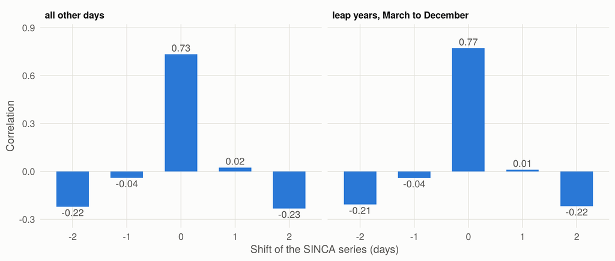

Figure 1: Correlation between day-to-day changes of CR2MET maximum temperature and SINCA station temperature, by shift of the SINCA series.

```r
lags <- read_table("temporal_alignment_lags.csv")
ggplot(lags, aes(factor(shift_days), correlation)) +
  geom_col(width = 0.6, fill = colour_method[["IDW"]]) +
  geom_text(aes(label = sprintf("%.2f", correlation), vjust = ifelse(correlation >= 0, -0.4, 1.3)),
            colour = ink$secondary, size = 3.2) +
  facet_wrap(~period) +
  scale_y_continuous(expand = expansion(mult = c(0.12, 0.15))) +
  labs(x = "Shift of the SINCA series (days)", y = "Correlation")
```

```r
kable(dcast(lags, period ~ shift_days, value.var = "correlation"), digits = 3)
```

Table 2: Values behind the figure.

| period | -2 | -1 | 0 | 1 | 2 |
| --- | --- | --- | --- | --- | --- |
| all other days | -0.222 | -0.040 | 0.733 | 0.024 | -0.233 |
| leap years, March to December | -0.208 | -0.041 | 0.772 | 0.011 | -0.218 |

The correlation peaks at a shift of zero in both periods: CR2MET dates are calendar dates and the only difference is the missing 29 February.

## 6 Temperature thresholds

Percentiles of the daily maximum temperature of each municipality over 1990-2020. The reference code computes them over all days of the year (`percentile_season: all_year`, the value in use); the table also gives the thresholds that the warm-season days alone would produce.

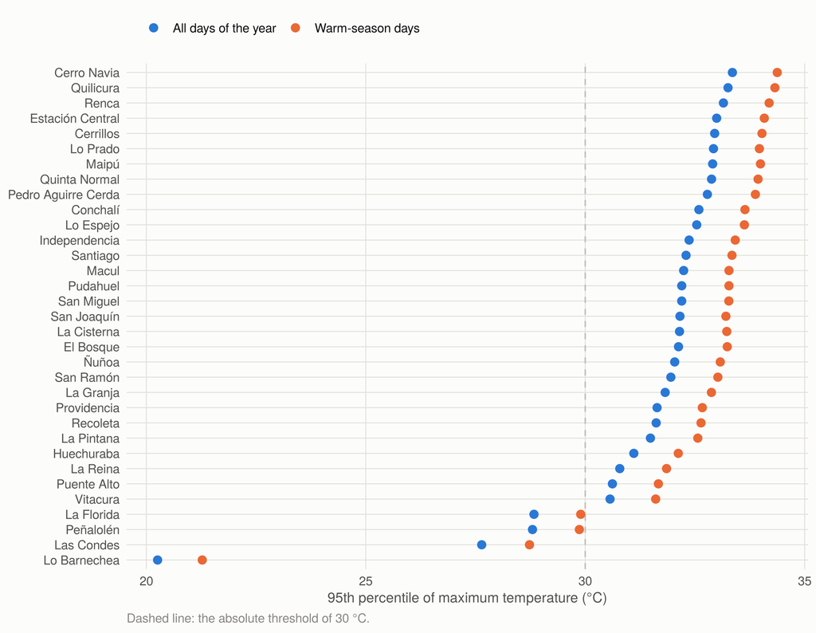

Figure 2: 95th percentile of daily maximum temperature by municipality, reference period 1990-2020, under the two season rules.

```r
thresholds <- read_table("temperature_thresholds.csv")
thresholds[, rule := fifelse(season_rule == "all_year", "All days of the year", "Warm-season days")]
order_mun <- thresholds[season_rule == "all_year"][order(p95), municipality]
ggplot(thresholds, aes(p95, factor(municipality, levels = order_mun), colour = rule)) +
  geom_vline(xintercept = get_param("temperature", "absolute_threshold_celsius"),
             colour = ink$axis, linetype = "dashed") +
  geom_point(size = 2.4) +
  scale_colour_manual(values = c("All days of the year" = "#2a78d6", "Warm-season days" = "#eb6834")) +
  labs(x = "95th percentile of maximum temperature (°C)", y = NULL, colour = NULL,
       caption = "Dashed line: the absolute threshold of 30 °C.")
```

```r
wide <- dcast(thresholds, com + municipality ~ season_rule, value.var = c("p90", "p95", "p99"))
kable(wide[order(com)], digits = 1,
      col.names = c("Code", "Municipality", "P90 all year", "P90 warm", "P95 all year",
                    "P95 warm", "P99 all year", "P99 warm"))
```

Table 3: Thresholds of maximum temperature by municipality (°C).

| Code | Municipality | P90 all year | P90 warm | P95 all year | P95 warm | P99 all year | P99 warm |
| --- | --- | --- | --- | --- | --- | --- | --- |
| 13101 | Santiago | 31.3 | 32.5 | 32.3 | 33.3 | 34.1 | 34.8 |
| 13102 | Cerrillos | 31.9 | 33.1 | 32.9 | 34.0 | 34.8 | 35.5 |
| 13103 | Cerro Navia | 32.3 | 33.5 | 33.4 | 34.4 | 35.2 | 35.9 |
| 13104 | Conchalí | 31.6 | 32.8 | 32.6 | 33.6 | 34.4 | 35.1 |
| 13105 | El Bosque | 31.1 | 32.4 | 32.1 | 33.2 | 34.0 | 34.7 |
| 13106 | Estación Central | 32.0 | 33.2 | 33.0 | 34.1 | 34.9 | 35.6 |
| 13107 | Huechuraba | 30.1 | 31.3 | 31.1 | 32.1 | 32.9 | 33.6 |
| 13108 | Independencia | 31.4 | 32.6 | 32.4 | 33.4 | 34.2 | 34.9 |
| 13109 | La Cisterna | 31.1 | 32.4 | 32.1 | 33.2 | 34.0 | 34.7 |
| 13110 | La Florida | 27.8 | 29.1 | 28.8 | 29.9 | 30.7 | 31.5 |
| 13111 | La Granja | 30.8 | 32.0 | 31.8 | 32.9 | 33.7 | 34.4 |
| 13112 | La Pintana | 30.4 | 31.7 | 31.5 | 32.6 | 33.4 | 34.0 |
| 13113 | La Reina | 29.8 | 31.0 | 30.8 | 31.9 | 32.6 | 33.4 |
| 13114 | Las Condes | 26.7 | 27.9 | 27.6 | 28.7 | 29.4 | 30.2 |
| 13115 | Lo Barnechea | 19.2 | 20.5 | 20.3 | 21.3 | 22.0 | 22.8 |
| 13116 | Lo Espejo | 31.5 | 32.8 | 32.5 | 33.6 | 34.4 | 35.1 |
| 13117 | Lo Prado | 31.9 | 33.1 | 32.9 | 34.0 | 34.7 | 35.5 |
| 13118 | Macul | 31.2 | 32.5 | 32.2 | 33.3 | 34.1 | 34.8 |
| 13119 | Maipú | 31.9 | 33.1 | 32.9 | 34.0 | 34.7 | 35.5 |
| 13120 | Ñuñoa | 31.0 | 32.3 | 32.0 | 33.1 | 33.8 | 34.6 |
| 13121 | Pedro Aguirre Cerda | 31.8 | 33.0 | 32.8 | 33.9 | 34.7 | 35.3 |
| 13122 | Peñalolén | 27.8 | 29.0 | 28.8 | 29.9 | 30.7 | 31.4 |
| 13123 | Providencia | 30.7 | 31.9 | 31.6 | 32.7 | 33.4 | 34.2 |
| 13124 | Pudahuel | 31.2 | 32.4 | 32.2 | 33.3 | 34.0 | 34.8 |
| 13125 | Quilicura | 32.3 | 33.5 | 33.3 | 34.3 | 35.1 | 35.8 |
| 13126 | Quinta Normal | 31.9 | 33.1 | 32.9 | 33.9 | 34.7 | 35.4 |
| 13127 | Recoleta | 30.6 | 31.8 | 31.6 | 32.6 | 33.4 | 34.1 |
| 13128 | Renca | 32.1 | 33.4 | 33.1 | 34.2 | 35.0 | 35.7 |
| 13129 | San Joaquín | 31.1 | 32.4 | 32.2 | 33.2 | 34.0 | 34.7 |
| 13130 | San Miguel | 31.2 | 32.4 | 32.2 | 33.3 | 34.1 | 34.7 |
| 13131 | San Ramón | 30.9 | 32.2 | 32.0 | 33.0 | 33.8 | 34.5 |
| 13132 | Vitacura | 29.6 | 30.8 | 30.6 | 31.6 | 32.3 | 33.1 |
| 13201 | Puente Alto | 29.6 | 30.8 | 30.6 | 31.7 | 32.5 | 33.3 |

CR2MET municipal values are means over the whole area of the municipality. Municipalities that reach into the Andes are therefore colder than their urban area: the 95th percentile ranges from 20.3 °C (Lo Barnechea) to 33.4 °C (Cerro Navia). A fixed threshold of 30 °C means very different things across municipalities, while the percentile thresholds adapt to each one.

## 7 Heatwave indicators

A day is a heatwave day when it is at least the n-th consecutive day above the threshold (n = 2, 3, 4), or when the excess heat factor of the last n days is positive. The first n − 1 days of a hot spell are not flagged, as in the reference code.

```r
hw_columns <- grep("^hw_", names(analysis), value = TRUE)
hw_table <- rbindlist(lapply(hw_columns, function(v) {
  per_mun <- analysis[, .(days = sum(get(v))), by = com]
  data.table(indicator = v, municipality_days = sum(per_mun$days),
             share_pct = 100 * sum(per_mun$days) / nrow(analysis),
             per_municipality_year = mean(per_mun$days) / 12,
             min_municipality = min(per_mun$days), max_municipality = max(per_mun$days))
}))
kable(hw_table, digits = c(0, 0, 1, 1, 0, 0), format.args = list(big.mark = ","),
      col.names = c("Indicator", "Municipality-days", "% of days", "Days per municipality and year",
                    "Fewest in a municipality (12 years)", "Most in a municipality (12 years)"))
```

Table 4: Heatwave days in the warm seasons of 2009-2020 under the 15 definitions.

| Indicator | Municipality-days | % of days | Days per municipality and year | Fewest in a municipality (12 years) | Most in a municipality (12 years) |
| --- | --- | --- | --- | --- | --- |
| hw_p90_2d | 10,820 | 18.1 | 27.3 | 309 | 362 |
| hw_p90_3d | 6,850 | 11.4 | 17.3 | 184 | 253 |
| hw_p90_4d | 4,929 | 8.2 | 12.4 | 124 | 195 |
| hw_p95_2d | 4,884 | 8.2 | 12.3 | 130 | 185 |
| hw_p95_3d | 2,635 | 4.4 | 6.7 | 62 | 123 |
| hw_p95_4d | 1,520 | 2.5 | 3.8 | 28 | 90 |
| hw_p99_2d | 670 | 1.1 | 1.7 | 14 | 37 |
| hw_p99_3d | 273 | 0.5 | 0.7 | 4 | 20 |
| hw_p99_4d | 109 | 0.2 | 0.3 | 1 | 10 |
| hw_30c_2d | 18,741 | 31.3 | 47.3 | 0 | 957 |
| hw_30c_3d | 14,098 | 23.5 | 35.6 | 0 | 788 |
| hw_30c_4d | 11,255 | 18.8 | 28.4 | 0 | 670 |
| hw_ehf_2d | 9,681 | 16.2 | 24.4 | 280 | 307 |
| hw_ehf_3d | 8,989 | 15.0 | 22.7 | 255 | 285 |
| hw_ehf_4d | 8,254 | 13.8 | 20.8 | 226 | 273 |

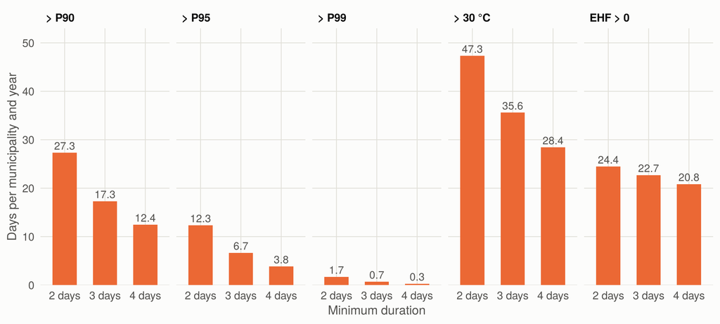

Figure 3: Heatwave days per municipality and year, by threshold and minimum duration.

```r
hw_table[, threshold := factor(sub("^hw_(.*)_[0-9]d$", "\\1", indicator),
                               levels = c("p90", "p95", "p99", "30c", "ehf"),
                               labels = c("> P90", "> P95", "> P99", "> 30 °C", "EHF > 0"))]
hw_table[, duration := paste0(sub(".*_([0-9])d$", "\\1", indicator), " days")]
ggplot(hw_table, aes(duration, per_municipality_year)) +
  geom_col(width = 0.6, fill = ramp_orange[4]) +
  geom_text(aes(label = sprintf("%.1f", per_municipality_year)), vjust = -0.4,
            colour = ink$secondary, size = 3) +
  facet_wrap(~threshold, nrow = 1) +
  scale_y_continuous(expand = expansion(mult = c(0, 0.12))) +
  labs(x = "Minimum duration", y = "Days per municipality and year")
```

### 7.1 Consecutive days must be counted within each municipality

The reference script (`HeatWave_PretermBirth_Chile`, `Code/2.0 HW_process_data.R`) builds the indicators with `lag()` on a table that holds all municipalities stacked and sorted by date. As published, the previous row of a municipality is therefore another municipality on the same day, not the same municipality on the previous day. The chunk below applies that logic and the within-municipality logic to the same temperatures and thresholds.

```r
# All municipalities of the Metropolitan Region, in the column order of the file
raw <- fread(input_path("cr2met_tmax"), header = FALSE)
file_codes <- as.integer(unlist(raw[1, -(1:3)]))
rm_codes <- file_codes[file_codes >= 13000 & file_codes < 14000]
stacked <- read_cr2met(input_path("cr2met_tmax"), "tmax", rm_codes)
stacked[, file_order := match(com, rm_codes)]
p95 <- thresholds[season_rule == get_param("temperature", "percentile_season"), .(com, p95)]
stacked <- merge(stacked, p95, by = "com", all.x = TRUE)
stacked[, hot := as.integer(tmax > p95)]

# As published: rows sorted by date, municipalities stacked, lag over rows
setorder(stacked, date, file_order)
for (n in 2:4) {
  stacked[, (paste0("rows_", n, "d")) := as.integer(Reduce(`+`, shift(hot, 0:(n - 1))) >= n)]
}
# Within municipality, over consecutive calendar rows of the file
setorder(stacked, com, date)
for (n in 2:4) {
  stacked[, (paste0("within_", n, "d")) := as.integer(Reduce(`+`, shift(hot, 0:(n - 1))) >= n),
          by = com]
}
compare <- stacked[com %in% study_municipalities()$code & year(date) %in% 2009:2020 &
                     month(date) %in% get_param("study", "warm_season_months")]
for (v in grep("^(rows|within)_", names(compare), value = TRUE)) {
  set(compare, which(is.na(compare[[v]])), v, 0L)
}
lag_compare <- rbindlist(lapply(2:4, function(n) {
  a <- compare[[paste0("rows_", n, "d")]]
  b <- compare[[paste0("within_", n, "d")]]
  data.table(duration = paste(n, "days"), hot_days = sum(compare$hot),
             stacked_rows = sum(a), within_municipality = sum(b),
             flagged_only_by_stacked = sum(a == 1 & b == 0),
             flagged_only_within = sum(a == 0 & b == 1))
}))
kable(lag_compare, format.args = list(big.mark = ","),
      col.names = c("Minimum duration", "Days above P95", "Lag over stacked rows",
                    "Lag within municipality", "Flagged only by stacked rows",
                    "Flagged only within municipality"))
```

Table 5: Heatwave days (> P95) in the 33 municipalities, warm seasons 2009-2020: lag over stacked rows against lag within municipality.

| Minimum duration | Days above P95 | Lag over stacked rows | Lag within municipality | Flagged only by stacked rows | Flagged only within municipality |
| --- | --- | --- | --- | --- | --- |
| 2 days | 9,809 | 8,364 | 4,851 | 4,216 | 703 |
| 3 days | 9,809 | 7,823 | 2,602 | 5,760 | 539 |
| 4 days | 9,809 | 7,364 | 1,487 | 6,283 | 406 |

With the stacked-row lag, a single hot day is flagged as a heatwave whenever the neighbouring municipalities in the file are also hot that day, so the number of heatwave days barely falls as the required duration grows. Counting within each municipality gives the indicators used in this project. The published indicators of the reference repository should be checked against this before they are reused.

## 8 Ozone and co-pollutants: delivered series

```r
pollution_qc <- read_table("air_pollution_qc.csv")
kable(pollution_qc, format.args = list(big.mark = ","),
      col.names = c("Version", "Variable", "Method", "Rows", "Missing as delivered",
                    "Below zero, set to missing", "Fewer stations than the minimum, set to missing"))
```

Table 6: Quality rules applied to the delivered interpolated series, all days of the dataset.

| Version | Variable | Method | Rows | Missing as delivered | Below zero, set to missing | Fewer stations than the minimum, set to missing |
| --- | --- | --- | --- | --- | --- | --- |
| opr | o3 | idw | 144,738 | 0 | 0 | 0 |
| opr | o3 | ok | 144,738 | 0 | 40 | 0 |
| opr | pm25 | idw | 144,738 | 0 | 0 | 0 |
| opr | pm25 | ok | 144,738 | 0 | 5 | 0 |
| opr | no2 | idw | 144,738 | 26 | 0 | 0 |
| opr | no2 | ok | 144,738 | 0 | 3 | 0 |
| opr | hum | idw | 144,738 | 0 | 0 | 0 |
| opr | hum | ok | 144,738 | 0 | 0 | 0 |
| all | o3 | idw | 144,738 | 0 | 0 | 0 |
| all | o3 | ok | 144,738 | 0 | 20 | 0 |
| all | pm25 | idw | 144,738 | 0 | 0 | 0 |
| all | pm25 | ok | 144,738 | 0 | 1 | 0 |
| all | no2 | idw | 144,738 | 0 | 0 | 0 |
| all | no2 | ok | 144,738 | 0 | 1 | 0 |
| all | hum | idw | 144,738 | 0 | 0 | 0 |
| all | hum | ok | 144,738 | 0 | 0 | 0 |

```r
variables <- c(o3 = "Ozone, 24-hour mean (ppb)", pm25 = "PM2.5 (µg/m³)",
               no2 = "Nitrogen dioxide (ppb)", hum = "Relative humidity (%)")
pollution_summary <- rbindlist(lapply(names(variables), function(v) {
  idw <- analysis[[paste0(v, "_idw")]]
  ok <- analysis[[paste0(v, "_ok")]]
  st <- analysis[[paste0(v, "_n_stations")]]
  data.table(variable = variables[[v]], idw_mean = mean(idw, na.rm = TRUE),
             ok_mean = mean(ok, na.rm = TRUE), idw_missing = sum(is.na(idw)),
             ok_missing = sum(is.na(ok)), stations = sprintf("%d to %d", min(st), max(st)),
             correlation = cor(idw, ok, use = "complete.obs"),
             mean_abs_difference = mean(abs(idw - ok), na.rm = TRUE))
}))
kable(pollution_summary, digits = 2, format.args = list(big.mark = ","),
      col.names = c("Variable", "Mean, IDW", "Mean, kriging", "Missing, IDW", "Missing, kriging",
                    "Stations per day", "Correlation IDW-kriging", "Mean absolute difference"))
```

Table 7: Delivered series in the warm seasons of 2009-2020: distribution, stations and agreement between the two interpolation methods.

| Variable | Mean, IDW | Mean, kriging | Missing, IDW | Missing, kriging | Stations per day | Correlation IDW-kriging | Mean absolute difference |
| --- | --- | --- | --- | --- | --- | --- | --- |
| Ozone, 24-hour mean (ppb) | 19.90 | 20.08 | 0 | 10 | 8 to 11 | 0.90 | 1.25 |
| PM2.5 (µg/m³) | 18.67 | 18.30 | 0 | 1 | 10 to 11 | 0.97 | 1.13 |
| Nitrogen dioxide (ppb) | 16.05 | 14.79 | 23 | 1 | 3 to 11 | 0.92 | 1.93 |
| Relative humidity (%) | 50.51 | 51.34 | 0 | 0 | 9 to 11 | 0.98 | 1.62 |

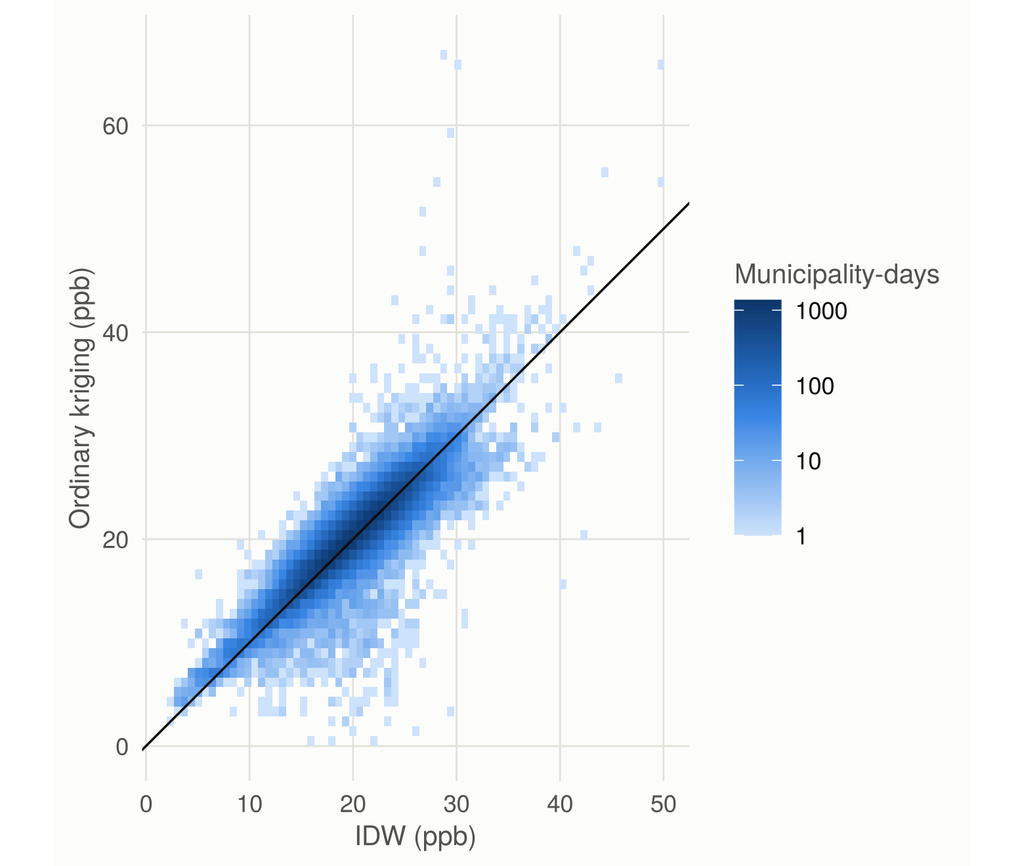

Figure 4: Ozone by ordinary kriging against ozone by IDW, delivered series, municipality-days of the warm seasons 2009-2020.

```r
ggplot(analysis[!is.na(o3_ok)], aes(o3_idw, o3_ok)) +
  geom_bin2d(bins = 70) +
  geom_abline(colour = ink$primary, linewidth = 0.4) +
  scale_fill_magnitude(name = "Municipality-days", trans = "log10") +
  coord_equal() +
  labs(x = "IDW (ppb)", y = "Ordinary kriging (ppb)") +
  theme(legend.position = "right", legend.justification = "center")
```

### 8.1 Version `opr` against version `all`

```r
all_version <- fread(derived_path("exposure_air_pollution_all.csv"), encoding = "UTF-8",
                     select = c("com", "date", "o3_idw", "o3_ok", "o3_n_stations"))
all_version[, date := as.Date(date)]
versions <- merge(analysis[, .(com, date, o3_idw, o3_ok, o3_n_stations)], all_version,
                  by = c("com", "date"), suffixes = c("_opr", "_all"))
version_table <- rbindlist(lapply(c("idw", "ok"), function(m) {
  a <- versions[[paste0("o3_", m, "_opr")]]
  b <- versions[[paste0("o3_", m, "_all")]]
  data.table(method = m, municipality_days = sum(!is.na(a) & !is.na(b)),
             identical_pct = 100 * mean(abs(a - b) < 1e-6, na.rm = TRUE),
             correlation = cor(a, b, use = "complete.obs"),
             mean_difference = mean(b - a, na.rm = TRUE),
             p95_abs_difference = quantile(abs(b - a), 0.95, na.rm = TRUE))
}))
kable(version_table, digits = c(0, 0, 1, 3, 2, 2), format.args = list(big.mark = ","),
      col.names = c("Method", "Municipality-days", "Identical (%)", "Correlation",
                    "Mean difference, all − opr (ppb)", "95th percentile of absolute difference (ppb)"))
```

Table 8: Ozone in the two delivered versions, warm seasons 2009-2020.

| Method | Municipality-days | Identical (%) | Correlation | Mean difference, all − opr (ppb) | 95th percentile of absolute difference (ppb) |
| --- | --- | --- | --- | --- | --- |
| idw | 59,895 | 74 | 0.988 | 0.02 | 0.74 |
| ok | 59,885 | 62 | 0.955 | -0.04 | 2.32 |

```r
station_counts <- rbind(
  versions[, .(version = "opr", stations = o3_n_stations_opr)],
  versions[, .(version = "all", stations = o3_n_stations_all)]
)[, .(n = .N), by = .(version, stations)]
station_counts[, share := 100 * n / sum(n), by = version]
kable(dcast(station_counts, stations ~ version, value.var = "share", fill = 0), digits = 1,
      col.names = c("Stations", "all", "opr"))
```

Table 9: Stations behind the ozone value, by version (share of municipality-days, %).

| Stations | all | opr |
| --- | --- | --- |
| 8 | 0 | 8.3 |
| 9 | 0 | 25.7 |
| 10 | 0 | 4.0 |
| 11 | 100 | 62.0 |

## 9 Ozone rebuilt from the hourly records

Script 12 rebuilds the station series from the hourly SINCA records, with no trimming and no imputation, as a 24-hour mean (`o3obs`) and as the daily maximum 8-hour mean (`o3mda8`), and interpolates them with the data author’s model and parameters. The reasons and the comparison with the delivered series are on the ozone validation page.

```r
status <- read_table("ozone_station_hourly_status.csv")
status_cols <- setdiff(names(status), c("sinca_id", "station"))
status[, total := rowSums(.SD), .SDcols = status_cols]
status_pct <- status[, c(.(station = station, hours = total),
                         lapply(.SD, function(x) 100 * x / total)), .SDcols = status_cols]
kable(status_pct, digits = 1, format.args = list(big.mark = ","))
```

Table 10: Hourly ozone records of the study period by validation status (% of hours).

| station | hours | no_record | not_validated | preliminary | validated |
| --- | --- | --- | --- | --- | --- |
| Independencia | 105,264 | 4.5 | 0.2 | 6.6 | 88.7 |
| La Florida | 105,264 | 6.0 | 2.7 | 1.1 | 90.2 |
| Las Condes | 105,264 | 2.7 | 0.0 | 0.6 | 96.7 |
| Parque O’Higgins | 105,264 | 4.2 | 0.4 | 4.3 | 91.1 |
| Pudahuel | 105,264 | 3.7 | 0.5 | 4.3 | 91.5 |
| Cerrillos I | 105,264 | 36.5 | 0.0 | 0.0 | 63.5 |
| El Bosque | 105,264 | 3.4 | 0.5 | 2.8 | 93.3 |
| Cerro Navia | 105,264 | 6.5 | 0.1 | 0.1 | 93.3 |
| Puente Alto | 105,264 | 6.9 | 0.2 | 1.0 | 91.8 |
| Talagante | 105,264 | 11.7 | 0.4 | 0.7 | 87.2 |
| Quilicura I | 105,264 | 40.2 | 0.0 | 0.6 | 59.2 |

```r
kable(read_table("ozone_rebuilt_qc.csv"), format.args = list(big.mark = ","),
      col.names = c("Series", "Method", "Rows", "Missing", "Below zero, set to missing",
                    "Days with fewer than 3 stations", "Days with a variogram warning",
                    "Days without a fitted variogram"))
```

Table 11: Rebuilt municipal series: missing values and kriging diagnostics, all days of the dataset.

| Series | Method | Rows | Missing | Below zero, set to missing | Days with fewer than 3 stations | Days with a variogram warning | Days without a fitted variogram |
| --- | --- | --- | --- | --- | --- | --- | --- |
| o3obs | idw | 144,738 | 80 | 0 | 2 | 0 | 0 |
| o3obs | ok | 144,738 | 66 | 18 | 2 | 0 | 0 |
| o3mda8 | idw | 144,738 | 98 | 0 | 2 | 1 | 1 |
| o3mda8 | ok | 144,738 | 99 | 12 | 2 | 1 | 1 |

## 10 The exposure dataset

`Data/Derived/exposure_2009_2020.csv` has 144,738 rows and 78 columns. The data folders are not tracked by git; the file is rebuilt by the scripts above.

```r
codebook <- read_table("exposure_codebook.csv")
kableExtra::scroll_box(
  kableExtra::kable_styling(kable(codebook, format = "html", format.args = list(big.mark = ","),
                                  col.names = c("Variable", "Description", "Missing")),
                            bootstrap_options = c("striped", "condensed"), font_size = 12),
  height = "420px"
)
```

Table 12: Codebook of the exposure dataset. Missing counts refer to all days of the dataset.

| Variable | Description | Missing |
| --- | --- | --- |
| com | Municipality code (INE) | 0 |
| municipality | Municipality name | 0 |
| date | Calendar day | 0 |
| year | Calendar year | 0 |
| in_study_period | Day inside the study years (FALSE for the lag buffer days) | 0 |
| warm_season | Day between 1 November and 31 March | 0 |
| tmax | Daily maximum temperature, CR2MET v2.5 (degrees C) | 0 |
| tmin | Daily minimum temperature, CR2MET v2.5 (degrees C) | 0 |
| temp_filled | Temperature absent from CR2MET (29 February), filled as configured | 0 |
| hot_p90 | Maximum temperature above the threshold in the name (1/0) | 0 |
| hot_p95 | Maximum temperature above the threshold in the name (1/0) | 0 |
| hot_p99 | Maximum temperature above the threshold in the name (1/0) | 0 |
| hot_30c | Maximum temperature above the threshold in the name (1/0) | 0 |
| hw_p90_2d | Heatwave day: at least the n-th consecutive day above the threshold (1/0) | 0 |
| hw_p90_3d | Heatwave day: at least the n-th consecutive day above the threshold (1/0) | 0 |
| hw_p90_4d | Heatwave day: at least the n-th consecutive day above the threshold (1/0) | 0 |
| hw_p95_2d | Heatwave day: at least the n-th consecutive day above the threshold (1/0) | 0 |
| hw_p95_3d | Heatwave day: at least the n-th consecutive day above the threshold (1/0) | 0 |
| hw_p95_4d | Heatwave day: at least the n-th consecutive day above the threshold (1/0) | 0 |
| hw_p99_2d | Heatwave day: at least the n-th consecutive day above the threshold (1/0) | 0 |
| hw_p99_3d | Heatwave day: at least the n-th consecutive day above the threshold (1/0) | 0 |
| hw_p99_4d | Heatwave day: at least the n-th consecutive day above the threshold (1/0) | 0 |
| hw_30c_2d | Heatwave day: at least the n-th consecutive day above the threshold (1/0) | 0 |
| hw_30c_3d | Heatwave day: at least the n-th consecutive day above the threshold (1/0) | 0 |
| hw_30c_4d | Heatwave day: at least the n-th consecutive day above the threshold (1/0) | 0 |
| tad | Daily mean temperature: (tmax + next-day tmin) / 2 (degrees C) | 0 |
| ehf_2d | Excess heat factor, window in the name (degrees C squared) | 0 |
| hw_ehf_2d | Heatwave day: excess heat factor above zero, window in the name (1/0) | 0 |
| ehf_3d | Excess heat factor, window in the name (degrees C squared) | 0 |
| hw_ehf_3d | Heatwave day: excess heat factor above zero, window in the name (1/0) | 0 |
| ehf_4d | Excess heat factor, window in the name (degrees C squared) | 0 |
| hw_ehf_4d | Heatwave day: excess heat factor above zero, window in the name (1/0) | 0 |
| o3_idw | Ozone, 24-hour mean, delivered interpolated series (ppb) | 0 |
| o3_ok | Ozone, 24-hour mean, delivered interpolated series (ppb) | 40 |
| o3_ok_var | Ordinary kriging variance | 40 |
| o3_n_stations | Stations with a value that day | 0 |
| pm25_idw | PM2.5, delivered interpolated series (ug/m3) | 0 |
| pm25_ok | PM2.5, delivered interpolated series (ug/m3) | 5 |
| pm25_ok_var | Ordinary kriging variance | 5 |
| pm25_n_stations | Stations with a value that day | 0 |
| no2_idw | Nitrogen dioxide, delivered interpolated series (ppb) | 26 |
| no2_ok | Nitrogen dioxide, delivered interpolated series (ppb) | 3 |
| no2_ok_var | Ordinary kriging variance | 3 |
| no2_n_stations | Stations with a value that day | 0 |
| hum_idw | Relative humidity, delivered interpolated series (percent) | 0 |
| hum_ok | Relative humidity, delivered interpolated series (percent) | 0 |
| hum_ok_var | Ordinary kriging variance | 0 |
| hum_n_stations | Stations with a value that day | 0 |
| o3obs_n_stations | Stations with a value that day | 0 |
| o3obs_idw | Ozone, 24-hour mean rebuilt from hourly records without trimming or imputation (ppb) | 80 |
| o3obs_ok | Ozone, 24-hour mean rebuilt from hourly records without trimming or imputation (ppb) | 84 |
| o3obs_ok_var | Ordinary kriging variance | 84 |
| o3obs_ok_warning | Variogram fit raised a warning that day | 66 |
| o3obs_ok_failed | Variogram could not be fitted that day (too few stations); kriging value missing | 66 |
| o3mda8_n_stations | Stations with a value that day | 0 |
| o3mda8_idw | Ozone, daily maximum 8-hour mean rebuilt from hourly records (ppb) | 98 |
| o3mda8_ok | Ozone, daily maximum 8-hour mean rebuilt from hourly records (ppb) | 111 |
| o3mda8_ok_var | Ordinary kriging variance | 111 |
| o3mda8_ok_warning | Variogram fit raised a warning that day | 66 |
| o3mda8_ok_failed | Variogram could not be fitted that day (too few stations); kriging value missing | 66 |
| o3_idw_gt_p50 | Ozone above the municipality percentile in the name, warm-season days of the study years (1/0) | 0 |
| o3_idw_gt_p75 | Ozone above the municipality percentile in the name, warm-season days of the study years (1/0) | 0 |
| o3_idw_gt_p90 | Ozone above the municipality percentile in the name, warm-season days of the study years (1/0) | 0 |
| o3obs_idw_gt_p50 | Ozone above the municipality percentile in the name, warm-season days of the study years (1/0) | 80 |
| o3obs_idw_gt_p75 | Ozone above the municipality percentile in the name, warm-season days of the study years (1/0) | 80 |
| o3obs_idw_gt_p90 | Ozone above the municipality percentile in the name, warm-season days of the study years (1/0) | 80 |
| o3mda8_idw_gt_p50 | Ozone above the municipality percentile in the name, warm-season days of the study years (1/0) | 98 |
| o3mda8_idw_gt_p75 | Ozone above the municipality percentile in the name, warm-season days of the study years (1/0) | 98 |
| o3mda8_idw_gt_p90 | Ozone above the municipality percentile in the name, warm-season days of the study years (1/0) | 98 |
| o3_ok_gt_p50 | Ozone above the municipality percentile in the name, warm-season days of the study years (1/0) | 40 |
| o3_ok_gt_p75 | Ozone above the municipality percentile in the name, warm-season days of the study years (1/0) | 40 |
| o3_ok_gt_p90 | Ozone above the municipality percentile in the name, warm-season days of the study years (1/0) | 40 |
| o3obs_ok_gt_p50 | Ozone above the municipality percentile in the name, warm-season days of the study years (1/0) | 84 |
| o3obs_ok_gt_p75 | Ozone above the municipality percentile in the name, warm-season days of the study years (1/0) | 84 |
| o3obs_ok_gt_p90 | Ozone above the municipality percentile in the name, warm-season days of the study years (1/0) | 84 |
| o3mda8_ok_gt_p50 | Ozone above the municipality percentile in the name, warm-season days of the study years (1/0) | 111 |
| o3mda8_ok_gt_p75 | Ozone above the municipality percentile in the name, warm-season days of the study years (1/0) | 111 |
| o3mda8_ok_gt_p90 | Ozone above the municipality percentile in the name, warm-season days of the study years (1/0) | 111 |

## 11 Points to settle

1. **29 February.** CR2MET has no leap days. They are filled by interpolation and flagged; the alternative is to leave them empty.
2. **Season of the percentiles.** All days of the year (reference code) or warm-season days only. The thresholds differ by about one degree.
3. **Heatwave indicators of the reference repository.** Its script counts consecutive days across stacked municipalities. This project counts them within each municipality.
4. **Fixed threshold of 30 °C.** With area-mean temperatures it is exceeded on 65% of the warm-season days in Quilicura and on 0% in Lo Barnechea.
5. **Ozone metric and inputs.** The delivered series is a 24-hour mean built on trimmed and imputed station series; the plan names the MDA8. See the ozone validation page.
6. **Negative kriging values.** Set to missing and counted in the tables above.
7. **Three buffer days of December 2008.** The monitoring network of PM2.5 and NO2 was smaller before 2009; those days only feed the lags of the first deaths of January 2009.